# Fun with R: Ecological data analysis in R

A title and a subtitle can be added to the map using the function `ggtitle`, passing any valid character string (e.g. with quotation marks) as arguments. Axis names are absent by default on a map, but can be changed to something more suitable (e.g. “Longitude” and “Latitude”), depending on the map:

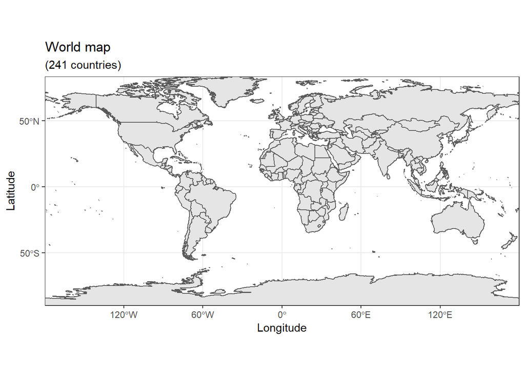

```r
ggplot(data = world) +
    geom_sf() +
    coord_sf(expand = FALSE) +
    xlab("Longitude") + ylab("Latitude") +
    ggtitle("World map", subtitle = paste0("(", length(unique(world$name)), " countries)"))
```

- Map color (`geom_sf`)

In many ways, `sf` geometries are no different than regular geometries, and can be displayed with the same level of control on their attributes. Here is an example with the polygons of the countries filled with a green color (argument `fill`), using black for the outline of the countries (argument `color`):

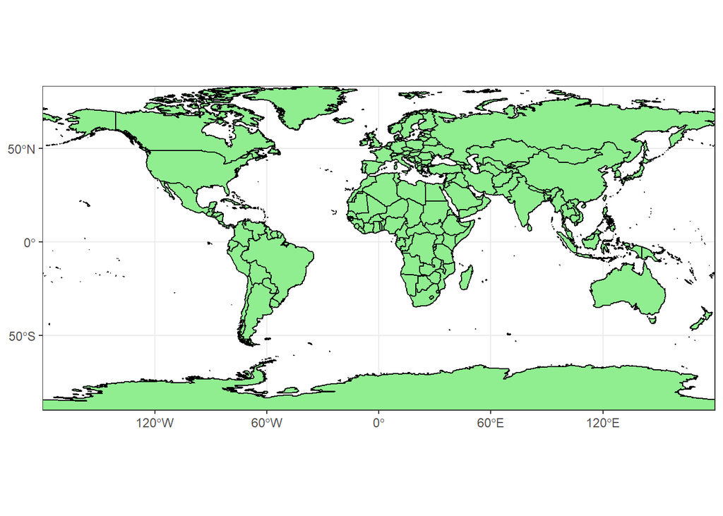

```r
ggplot(data = world) +
    geom_sf(color = "black", fill = "lightgreen") +
    coord_sf(expand = FALSE)
```

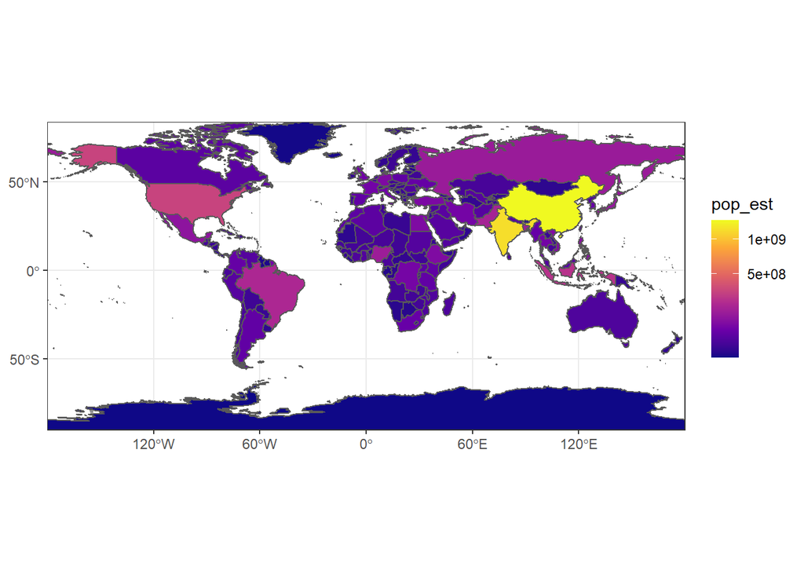

```r
ggplot(data = world) +
    geom_sf(aes(fill = pop_est)) +
    coord_sf(expand = FALSE) +
    scale_fill_viridis_c(option = "plasma", trans = "sqrt")
```

- Projection and extend (`coord_sf`)

The function `coord_sf` allows to deal with the coordinate system, which includes both projection and extent of the map. By default, the map will use the coordinate system of the first layer that defines one (i.e. scanned in the order provided), or if none, fall back on WGS84 (latitude/longitude, the reference system used in GPS). Using the argument `crs`, it is possible to override this setting, and project on the fly to any projection. This can be achieved using any valid PROJ4 string (here, the European-centric ETRS89 Lambert Azimuthal Equal-Area projection):

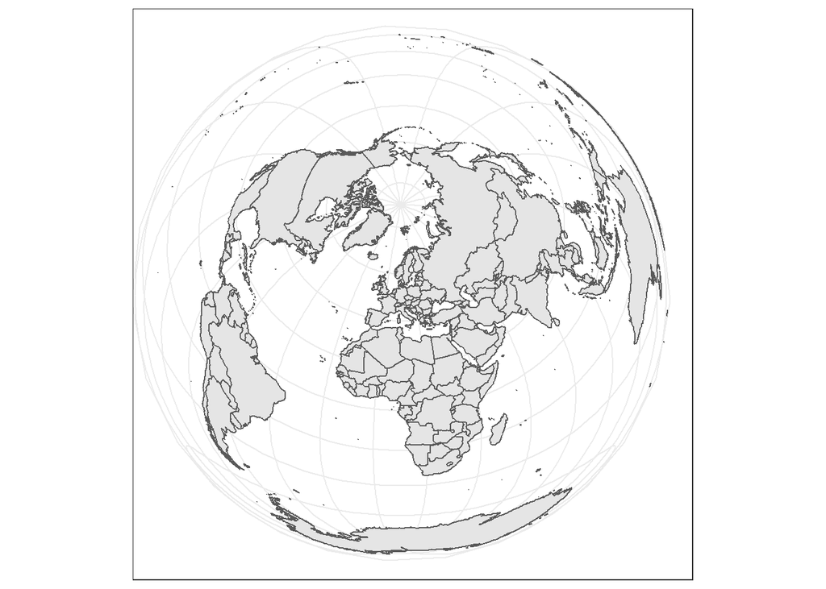

```r
ggplot(data = world) +
    geom_sf() +
    scale_fill_viridis_c(option = "plasma", trans = "sqrt") +
    coord_sf(crs = "+proj=laea +lat_0=52 +lon_0=10 +x_0=4321000 +y_0=3210000 +ellps=GRS80 +units=m +no_defs ")
```

Spatial Reference System Identifier (SRID) or an European Petroleum Survey Group (EPSG) code are available for the projection of interest, they can be used directly instead of the full PROJ4 string. The two following calls are equivalent for the ETRS89 Lambert Azimuthal Equal-Area projection, which is EPSG code 3035:

```r
ggplot(data = world) +
    geom_sf() +
    coord_sf(crs = "+init=epsg:3035")

ggplot(data = world) +
    geom_sf() +
    coord_sf(crs = st_crs(3035))
```

The extent of the map can also be set in `coord_sf`, in practice allowing to “zoom” in the area of interest, provided by limits on the x-axis (`xlim`), and on the y-axis (`ylim`). Note that the limits are automatically expanded by a fraction to ensure that data and axes don’t overlap; it can also be turned off to exactly match the limits provided with `expand = FALSE`:

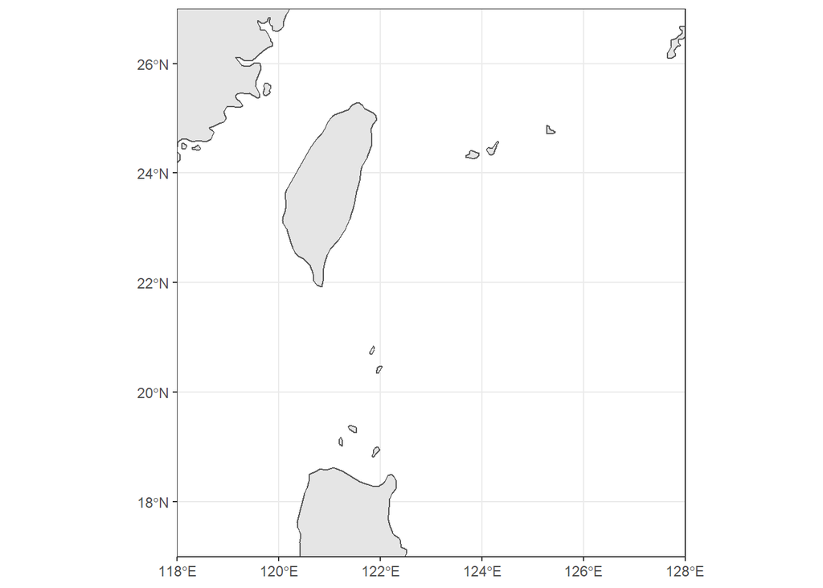

```r
ggplot(data = world) +
    geom_sf() +
    coord_sf(xlim = c(118, 128), ylim = c(17, 27), expand = FALSE)
```

- Scale bar and North arrow (package `ggspatial`)

```r
library(ggspatial)
```

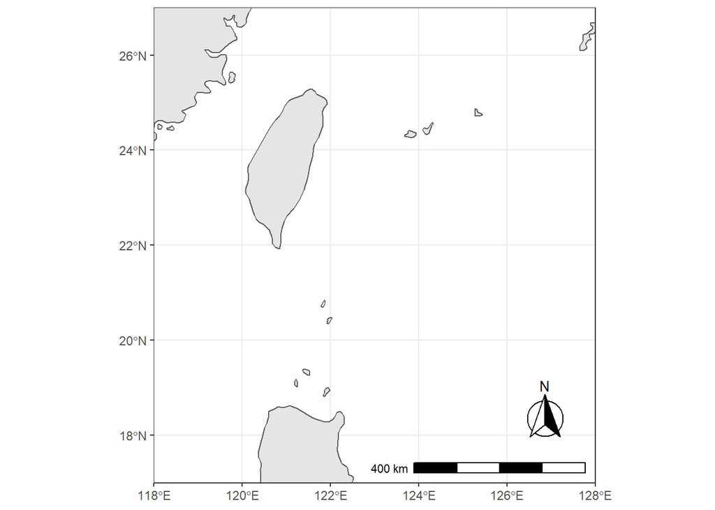

```r
ggplot(data = world) +
    geom_sf() +
    annotation_scale(location = "br", width_hint = 0.4) +
    annotation_north_arrow(location = "br", which_north = "true",
        pad_x = unit(0.5, "cm"), pad_y = unit(1, "cm"),
        style = north_arrow_fancy_orienteering) +
    coord_sf(xlim = c(118, 128), ylim = c(17, 27), expand = FALSE)
```

If you plot a larger area, you may get a warning on the inaccuracy of the scale bar.

- Country names and other names (geom_text and annotate) The `world` data set already contains country names and the coordinates of the centroid of each country (among more information). We can use this information to plot country names, using `world` as a regular `data.frame` in `ggplot2`. The function `geom_text` can be used to add a layer of text to a map using geographic coordinates. The function requires the data needed to enter the country names, which is the same data as the world map. Again, we have a very flexible control to adjust the text at will on many aspects:
  - The size (argument `size`);
  - The alignment, which is centered by default on the coordinates provided. The text can be adjusted horizontally or vertically using the arguments `hjust` and `vjust`, which can either be a number between 0 (right/bottom) and 1 (top/left) or a character (“left”, “middle”, “right”, “bottom”, “center”, “top”). The text can also be offset horizontally or vertically with the argument `nudge_x` and `nudge_y`;
  - The font of the text, for instance its color (argument `color`) or the type of font (`fontface`);
  - The overlap of labels, using the argument `check_overlap`, which removes overlapping text. Alternatively, when there is a lot of overlapping labels, the package `ggrepel` provides a `geom_text_repel` function that moves label around so that they do not overlap.
  - For the text labels, we are defining the centroid of the countries with `st_centroid`, from the package `sf`. Then we combined the coordinates with the centroid, in the `geometry` of the spatial data frame. The package `sf` is necessary for the command `st_centroid`.

```r
library("sf")
world_points<- st_centroid(world)
world_points <- cbind(world, st_coordinates(st_centroid(world$geometry)))
```

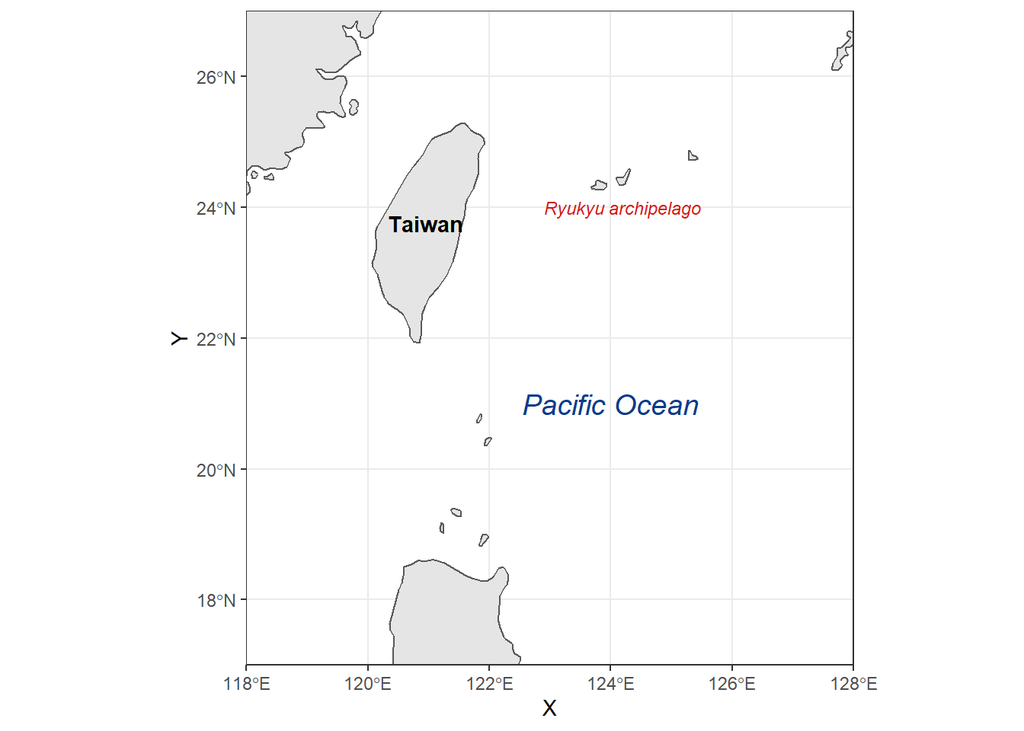

```r
ggplot(data = world) +
geom_sf() +
geom_text(data= world_points,aes(x=X, y=Y, label=name),
    color = "black", fontface = "bold", check_overlap = FALSE) +
    annotate(geom = "text", x = 124, y = 21, label = "Pacific Ocean", fontface = "italic", color = "#0b3c8a", size = 5) +
   annotate(geom = "text", x = 124.2, y = 24, label = "Ryukyu archipelago", fontface = "italic", color = "#d41919", size = 3) +
   coord_sf(xlim = c(118, 128), ylim = c(17, 27), expand = FALSE)
```

- Finalization

Now to make the final touches, the theme of the map can be edited to make it more appealing. We suggested the use of `theme_bw` for a standard theme, but there are many other themes that can be selected from (see for instance `?ggtheme` in `ggplot2`, or the package `ggthemes` which provide several useful themes). Moreover, specific theme elements can be tweaked to get to the final outcome:

- Position of the legend: Although not used in this example, the argument `legend.position` allows to automatically place the legend at a specific location (e.g. “topright”, “bottomleft”, etc.);
- Grid lines (graticules) on the map: by using `panel.grid.major` and `panel.grid.minor`, grid lines can be adjusted. Here we set them to a gray color and dashed line type to clearly distinguish them from country borders lines;
- Map background: the argument `panel.background` can be used to color the background, which is the ocean essentially, with a light blue; Many more elements of a theme can be adjusted, which would be too long to cover here. We refer the reader to the documentation for the function `theme`.

```
## Scale on map varies by more than 10%, scale bar may be inaccurate
```

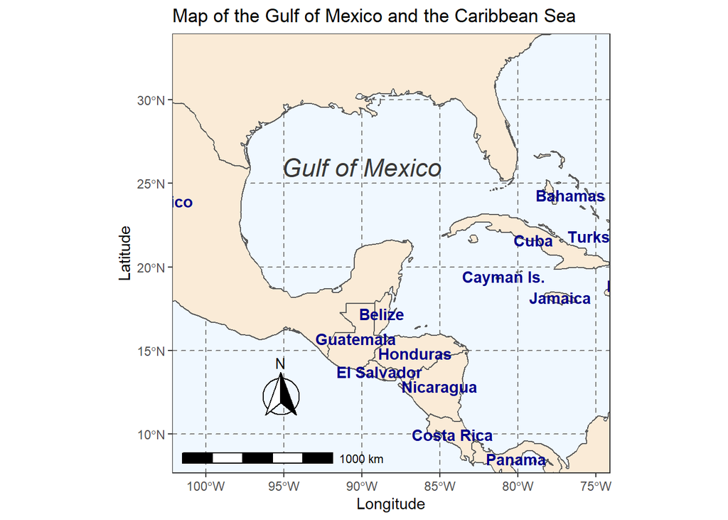

```r
ggplot(data = world) +
   geom_sf(fill= 'antiquewhite') +
   geom_text(data= world_points,aes(x=X, y=Y, label=name), color = 'darkblue', fontface = 'bold', check_overlap = FALSE) +
   annotate(geom = 'text', x = -90, y = 26, label = 'Gulf of Mexico', fontface = 'italic', color = 'grey22', size = 6) +
   annotation_scale(location = 'bl', width_hint = 0.5) +
   annotation_north_arrow(location = 'bl', which_north = 'true', pad_x = unit(0.75, 'in'), pad_y = unit(0.5, 'in'), style = north_arrow_fancy_orienteering) +
   coord_sf(xlim = c(-102.15, -74.12), ylim = c(7.65, 33.97), expand = FALSE) +
   xlab('Longitude') + ylab('Latitude') +
   ggtitle('Map of the Gulf of Mexico and the Caribbean Sea') +
   theme(panel.grid.major = element_line(color = gray(.5), linetype = 'dashed', size = 0.5), panel.background = element_rect(fill = 'aliceblue'))
```

- Exporting map

The final map is now ready, it is very easy to save it using ggsave. This function allows a graphic (typically the last plot displayed) to be saved in a variety of formats, including the most common PNG (raster bitmap) and PDF (vector graphics), with control over the size and resolution of the outcome. For instance here, we save a PDF version of the map, which keeps the best quality, and a PNG version of it for web purposes:

```r
ggsave("Output/Datamap.pdf")
```

```
## Scale on map varies by more than 10%, scale bar may be inaccurate
```

```r
ggsave("Output/map_web.png", width = 6, height = 6, dpi = "screen")
```

```
## Scale on map varies by more than 10%, scale bar may be inaccurate
```

### Species distribution

```r
library(rgbif)
```

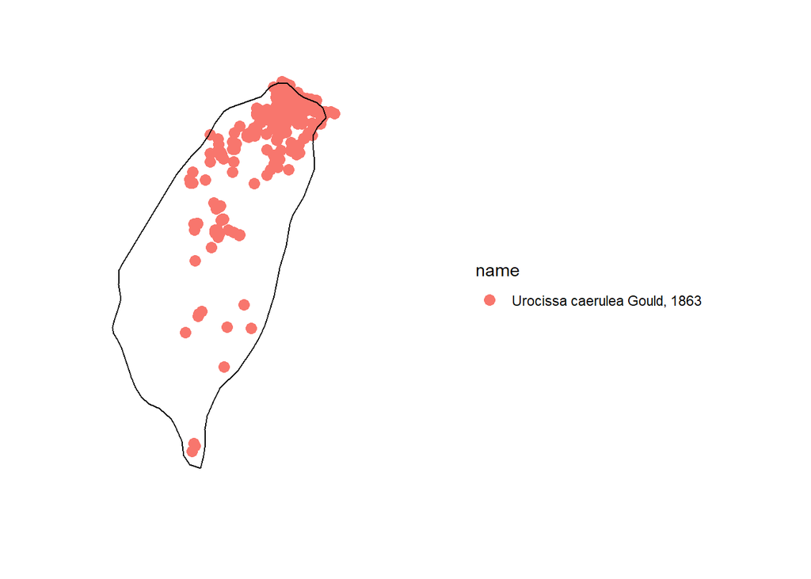

```r
library(ggplot2)
library(mapr)
gbif.res <- occ_search(scientificName = "Urocissa caerulea", limit = 1200)

map_ggplot(gbif.res) +
  coord_sf(xlim = c(120, 123), ylim = c(21, 26), expand = FALSE)
```

Have a look [here](https://damariszurell.github.io/HU-GCIB/1_Data.html#2_environmental_data), to combine climate and species data. I have been trying to do it for few days but packages need API keys. This tutorial (not ggplot) should work - but not tested.

### Bathymetric map with `marmap`

`marmap` can query and plot NOAA’s bathymetry database

```r
library(marmap)
# download data
TW.bathy <- getNOAA.bathy(lon1=118,lon2=124, lat1=21,lat2=26,resolution=1) # don't put too wide / resolution: 1
```

```
## Querying NOAA database ...
```

```
## This may take seconds to minutes, depending on grid size
```

```
## Building bathy matrix ...
```

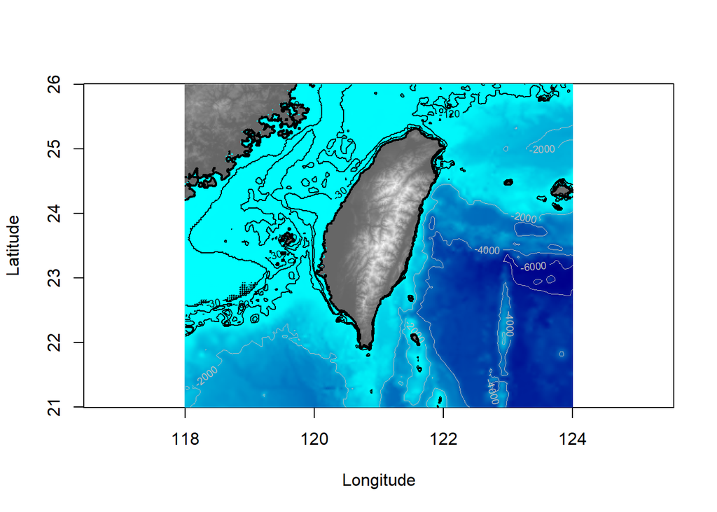

```r
# define palette
blues <- colorRampPalette(c("darkblue", "cyan"))
greys <- colorRampPalette(c(grey(0.4),grey(0.99)))
# make the plot
plot.bathy(TW.bathy,
     image=T,
     deepest.isobath=c(-6000,-120,-30,0),
     shallowest.isobath=c(-1000,-60,0,0),
     step=c(2000,60,30,0),
     lwd=c(0.3,1,1,2),
     lty=c(1,1,1,1),
     col=c("grey","black","black","black"),
     drawlabels=c(T,T,T,F),
     bpal = list(c(0,max(TW.bathy),greys(100)),c(min(TW.bathy),0,blues(100))),
     land=T, xaxs="i"
     )
```

Profiles can be extract using `get.transect`:

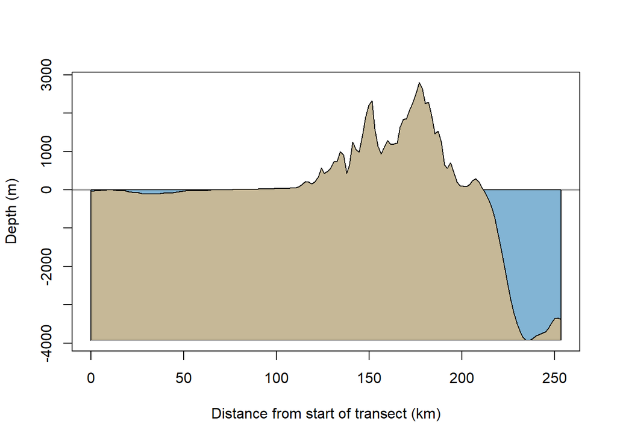

```r
tw.profile <-get.transect(TW.bathy,x1=119.5,y1=23.75, x2=122,y2=23.75, dis=TRUE)
plotProfile(tw.profile)
```

```r
#### Not Run: extract a profile Manually
#### manual.profile<-get.transect (TW.bathy, loc=T,dist=T)
#### plotProfile(manual.profile)
```

### Interactive maps

```r
library(sf)
library(RColorBrewer)
library(dplyr)
library(devtools)
library(ggsflabel)
```

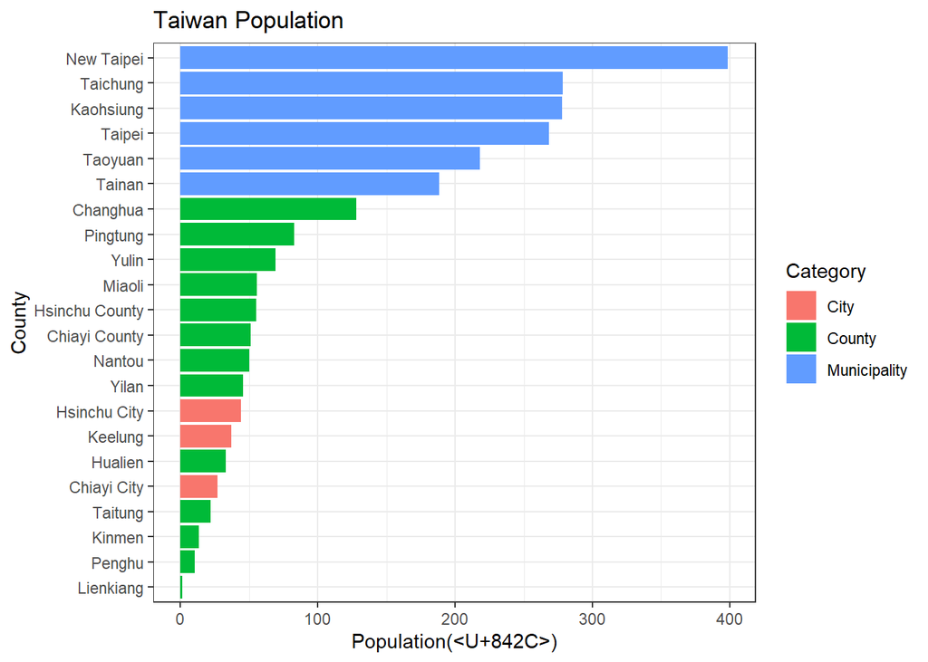

```r
# devtools::install_github("yutannihilation/ggsflabel") #None

df.pop <- read.csv("Data/tw_population.csv", h = T)
df.pop <- data.frame(df.pop)

ggplot(df.pop, aes(x = reorder(County, Population), y = Population/10000, fill = Category)) +
  geom_bar(stat="identity") +
  coord_flip() +
  labs(title = "Taiwan Population", x = "County", y = "Population(萬)")
```

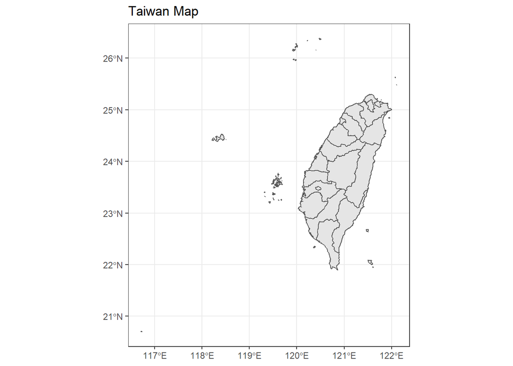

```r
taiwan.map <- st_read ("Data/GADM/gadm36_TWN_2.shp")
ggplot(data = taiwan.map) +
  geom_sf() +
  labs(title = "Taiwan Map ")
```

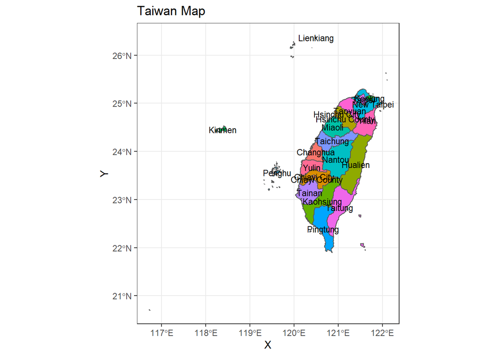

```r
ggplot(data = taiwan.map) +
  geom_sf(aes(fill = NAME_2), show.legend= F) +
  geom_sf_text(aes(label = NAME_2), size = 3) +
  labs(title = "Taiwan Map ")
```

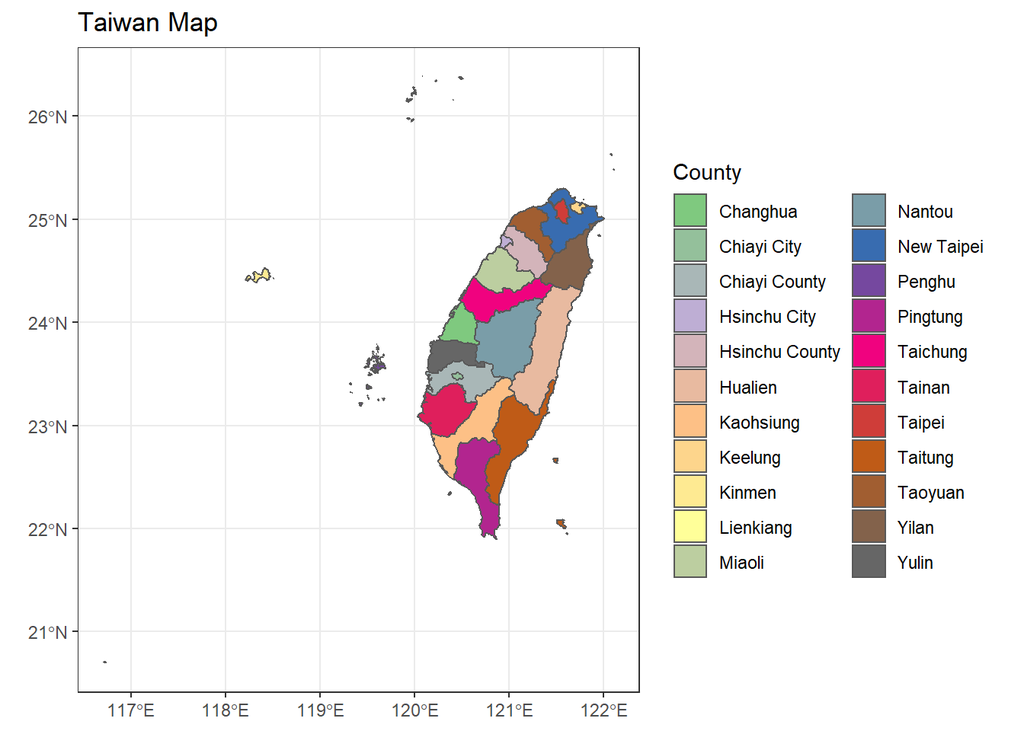

```r
ggplot(data = taiwan.map) +
  geom_sf(aes(fill = NAME_2)) +
  scale_fill_manual(name = "County",values = colorRampPalette(brewer.pal(8, "Accent"))(22)) +
  labs(title = "Taiwan Map ")
```

Combine the two datasets:

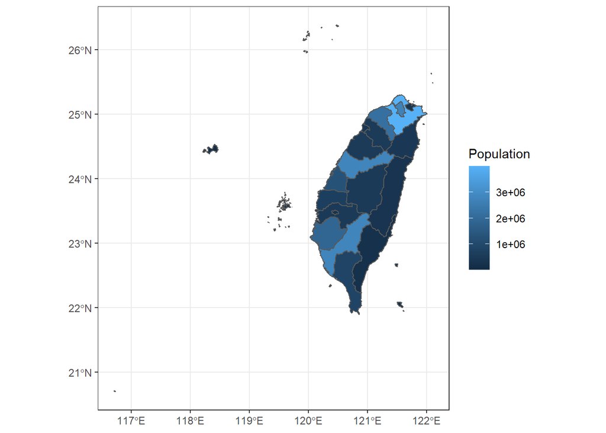

```r
my.taiwan.map <- taiwan.map[c("NAME_2", "geometry")]
my.taiwan.map$NAME_2 <- as.character(my.taiwan.map$NAME_2)
my.taiwan.map.data <- left_join(my.taiwan.map, df.pop,by= c("NAME_2" = "County"))

ggplot(data = my.taiwan.map.data) +
  geom_sf(aes(fill = Population))
```

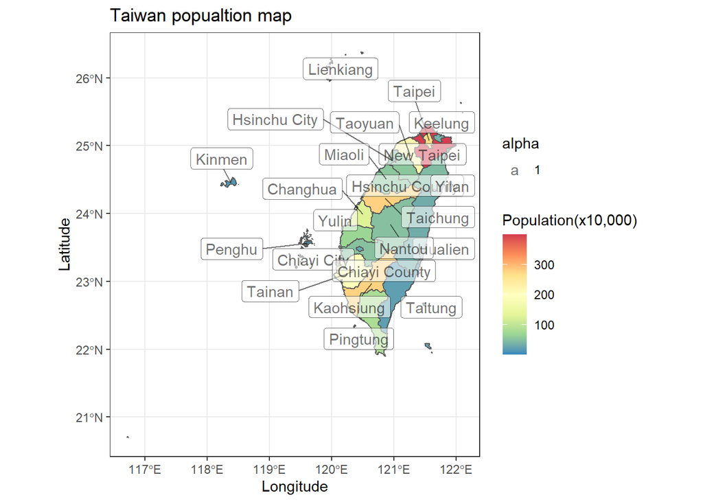

```r
ggplot(data = my.taiwan.map.data) +
  geom_sf(aes(fill = Population/10000)) +
  scale_fill_distiller(palette = "Spectral", name = "Population(x10,000)") +
  geom_sf_label_repel(aes(label = NAME_2, alpha = 1)) +
  labs(title="Taiwan popualtion map", x ="Longitude", y = "Latitude")
```

Make it interactive:

```r
# not run
# library(mapview)
# library(fields)
# mapview(my.taiwan.map.data["Population"])
# mapview(my.taiwan.map.data["Population"], col.regions = tim.colors(100))
```